# Tutorial for identifying genes with spatial expression trends using trendsceek

Daniel Edsgärd

2018-03-01

## Synthetic data

```r
##Load library
library('trendsceek')
```

### Create syntethic data

Below we simulate a step, hotspot and streak of cells with higher expression than the background.

```r
##Set parameters
##approximate number of cells
nsim_cells = 300

##low and high expression levels
low_expr = c(10, 10)
high_expr = c(20, 50)

##Randomly position the cells in 2d space
pp = sim_pois(nsim_cells)

##Add gene expression levels as mark distributions
pp = add_markdist_step(pp, low_expr, high_expr)
pp = add_markdist_hotspot(pp, low_expr, high_expr)
pp = add_markdist_streak(pp, low_expr, high_expr)
```

Plot synthetic data

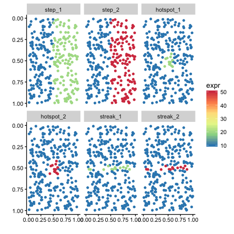

```r
plot_pp_scatter(pp, log_marks = FALSE, scale_marks = FALSE, pal.direction = -1)
```

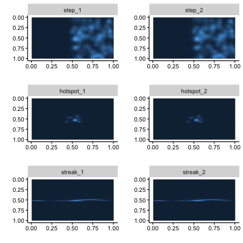

```
## [1] 1
## [1] 2
## [1] 3
## [1] 4
## [1] 5
## [1] 6
```

```r
plot_pp_density(pp, log_marks = FALSE)
```

### Run trendsceek

```r
##set parameters
nrand = 100
ncores = 1

##run
trendstat_list = trendsceek_test(pp, nrand, ncores)

##extract significant genes
alpha = 0.1 ##Benjamini-Hochberg
sig_list = extract_sig_genes(trendstat_list, alpha)
```

Plot trend-statistics for significant genes in synthetic dataset

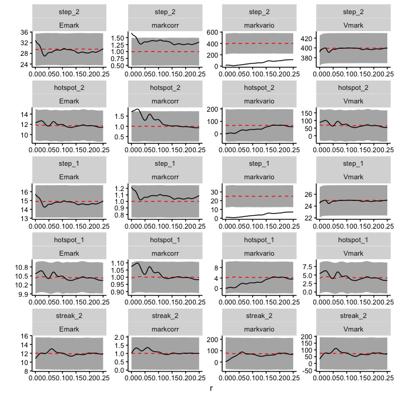

```r
sig_genes = sig_list[['markcorr']][, 'gene']
plot_trendstats(trendstat_list, sig_genes)
```

The grey band indicates a null-distribution with Bonferroni-adjusted limits and may therefore be more conservative than the Benjamini-Hochberg P-value used to extract the significant genes.

## Real data

### Data preparation

#### Read data

```r
data('scialdone')
counts = scialdone[['counts']]
```

#### Gene variability stats

Filter genes on being expressed

```r
##Pass genes having at least 3 cells with minimum 5 in read count
min.ncells.expr = 3
min.expr = 5
counts_filt = genefilter_exprmat(counts, min.expr, min.ncells.expr)
dim(counts_filt)
```

```
## [1] 17625   481
```

Calculate gene variability stats

```r
quantile.cutoff = 0.9 ##filter out the most lowly expressed genes from the fitting
method = 'glm' ##For (robust) linear regression set to 'rlm'
vargenes_stats = calc_varstats(counts_filt, counts_filt, quant.cutoff = quantile.cutoff, method = method)
```

```
## [1] 3735
##  expl.var
## 0.5733161
```

Select subset with the top-ranked most variable genes

```r
n.topvar = 500
topvar.genes = rownames(vargenes_stats[['real.stats']])[1:n.topvar]
```

Plot gene variability stats, highlighting the 500 most variable genes

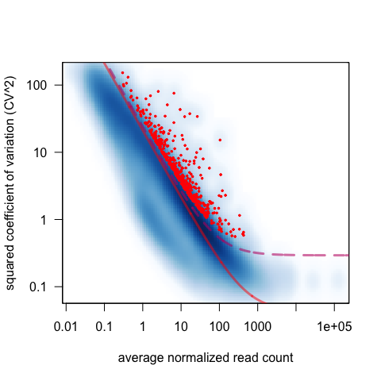

```r
plot.ercc.points = FALSE
plot_cv2vsmean(vargenes_stats, topvar.genes, plot.ercc.points = plot.ercc.points)
```

#### Normalize the read counts

```r
min.count = 1
counts_norm = deseq_norm(counts, min.count)
```

#### Subset normalized counts on the most variable genes

```r
counts_sub = counts_norm[topvar.genes, ]
dim(counts_sub)
```

```
## [1] 500 481
```

#### tSNE dimensionality reduction

```r
##params
tsne.k = 2 #Number of tSNE dimensions
init.dims = 100 #Number of PCA-dimensions to reduce to before tSNE
perp.frac = 0.2 #Fraction of cells
max.iter = 300 #Maximum number of iterations
epoch = 50 #print status every epoch iteration

##run tsne including initial pca
tsne_res = trend.tsne(counts_sub, tsne.k, init.dims, perp.frac, max.iter, epoch)
```

```
## nsamples: 481
## perp: 96
## n.dims input: 100
```

```
## sigma summary: Min. : 0.1205 |1st Qu. : 0.1358 |Median : 0.1416 |Mean : 0.1452 |3rd Qu. : 0.1499 |Max. : 0.2495 |
```

```
## Epoch: Iteration #50 error is: 19.6331760316857
```

```
## Epoch: Iteration #100 error is: 20.841732981132
```

```
## Epoch: Iteration #150 error is: 1.41447429316851
```

```
## Epoch: Iteration #200 error is: 1.08751049221541
```

```
## Epoch: Iteration #250 error is: 0.825800082378364
```

```
## Epoch: Iteration #300 error is: 0.828989450104515
```

If the error does not seem to have converged increase the argument ‘max.iter’

#### Create point-pattern using tSNE positions as spatial distribution and expression levels as mark distribution

```r
##Convert tSNE cell positions to point pattern
pp = pos2pp(tsne_res)

##Set marks as the logged normalized gene expression
log.fcn = log10
pp = set_marks(pp, counts_sub, log.fcn = log.fcn)
```

#### Plot top variable genes in tSNE space

```r
##Subset on top variable genes
n.top2plot = 10
topvar.genes = rownames(vargenes_stats[['real.stats']])[1:n.top2plot]
pp2plot = pp_select(pp, topvar.genes)
```

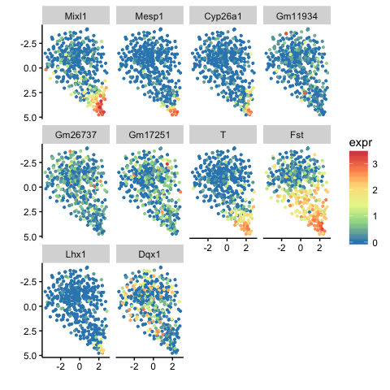

```r
plot_pp_scatter(pp2plot, log_marks = FALSE, scale_marks = FALSE, pal.direction = -1)
```

A number of the most variable genes do not seem to have a spatial trend, e.g. Dqx1 and the Gm* genes. To find genes that have a spatial trend in an automated fashion and to assess the significance of the spatial trend we run trendsceek.

### Run trendsceek

To decrease the time it takes to run this vignette-example we run trendsceek using just the 10 most variable genes and with 100 permutations.

```r
##set parameters
nrand = 100
ncores = 1

##run
trendstat_list = trendsceek_test(pp2plot, nrand, ncores)
```

### Analyze trendsceek results

A table with gene test-statistics and p-values is output by trendsceek_test.

```r
head(trendstat_list[['supstats_wide']])
```

```
##      gene earlystop_Emark earlystop_Vmark earlystop_markcorr
## 1   Mesp1               0               0                  0
## 2 Cyp26a1               0               0                  0
## 3   Mixl1               0               0                  0
## 4    Lhx1               0               0                  0
## 5       T               0               0                  0
## 6     Fst               0               0                  0
##   earlystop_markvario max.env.rel.dev_Emark max.env.rel.dev_Vmark
## 1                   0             0.4975524             0.4446473
## 2                   0             0.2416630             0.2491099
## 3                   0             0.6000129             0.5099811
## 4                   0             0.4479146             0.5329303
## 5                   0             0.5113953             0.4678257
## 6                   0             1.4579280             0.4669278
##   max.env.rel.dev_markcorr max.env.rel.dev_markvario max.rel.dev_Emark
```

[output cut: 55 more lines]

Extract significant genes

```r
alpha = 0.05 ##Benjamini-Hochberg
sig_list = extract_sig_genes(trendstat_list, alpha)
```

Number of significant genes

```r
lapply(sig_list, nrow)
```

```
## $markcorr
## [1] 6
##
## $markvario
## [1] 4
```

#### Significant mark-correlation genes

```r
##get significant genes
sig_genes = sig_list[['markcorr']][, 'gene']
```

Plot trend-statistics for significant genes

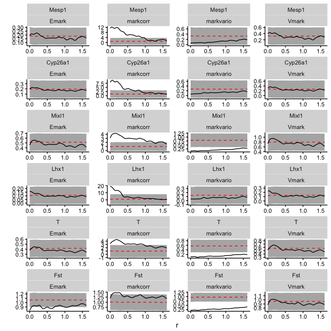

```r
plot_trendstats(trendstat_list, sig_genes)
```

Create marked point-pattern containing subset of significant genes

```r
pp_sig = pp_select(pp, sig_genes)
```

Scatter-plot with unscaled expression levels

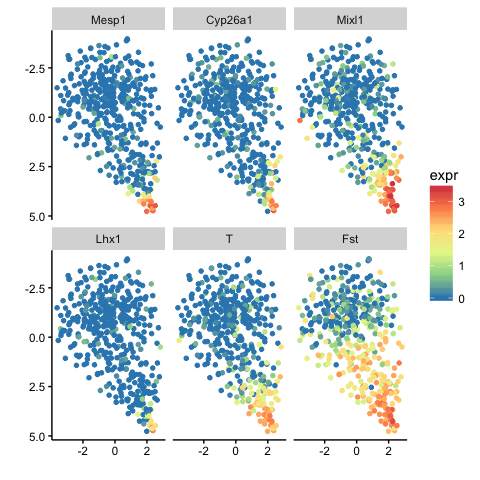

```r
plot_pp_scatter(pp_sig, log_marks = FALSE, scale_marks = FALSE, pal.direction = -1)
```

Plots with scaled expression per gene

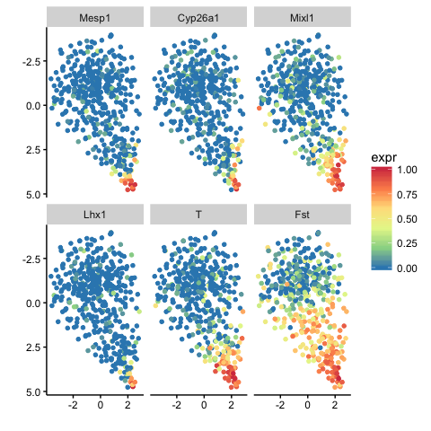

```r
plot_pp_scatter(pp_sig, log_marks = FALSE, scale_marks = TRUE, pal.direction = -1)
```

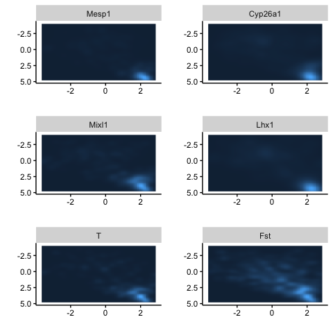

```
## [1] 1
## [1] 2
## [1] 3
## [1] 4
## [1] 5
## [1] 6
```

```r
plot_pp_density(pp_sig, log_marks = FALSE)
```

#### Identify and highlight cells located in regions exceeding background level

The function “cellsceek_test” creates a (cell x gene) table with values of 1 if a cell is in a region exceeding the background level and 0 otherwise.

```r
nrand = 100
cellpeaks_siggenes = cellsceek_test(pp_sig, nrand = nrand)
sig_cells = get_sigcells(cellpeaks_siggenes)
```

```r
head(sig_cells, 10)
```

```
##                    Mesp1 Cyp26a1 Mixl1 Lhx1 T Fst
## SLX.8351.N701_N503     0       0     0    0 0   0
## SLX.8351.N701_N504     0       0     0    0 0   0
## SLX.8351.N701_N505     0       0     0    0 0   0
## SLX.8351.N701_N506     0       0     0    0 0   0
## SLX.8351.N701_N517     0       0     0    0 0   0
## SLX.8351.N702_N503     0       0     0    0 0   1
## SLX.8351.N702_N506     0       0     1    0 1   1
## SLX.8351.N702_N507     0       0     0    0 0   0
## SLX.8351.N702_N508     0       0     1    0 1   1
## SLX.8351.N702_N517     0       0     0    0 0   0
```

Plot position of cells located in regions exceeding the null distribution background level

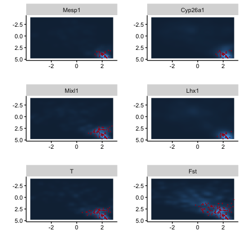

```
## [1] 1
## [1] 2
## [1] 3
## [1] 4
## [1] 5
## [1] 6
```

```r
plot_pp_density(pp_sig, log_marks = FALSE, cells2highlight = sig_cells)
```

#### Significant mark-variogram genes

```r
##get significant genes
sig_genes = sig_list[['markvario']][, 'gene']
```

Plot trend-statistics for significant genes

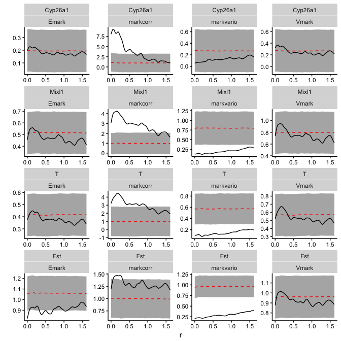

```r
plot_trendstats(trendstat_list, sig_genes)
```

Create marked point-pattern containing subset of significant genes

```r
pp_sig = pp_select(pp, sig_genes)
```

Scatter-plot with unscaled expression levels

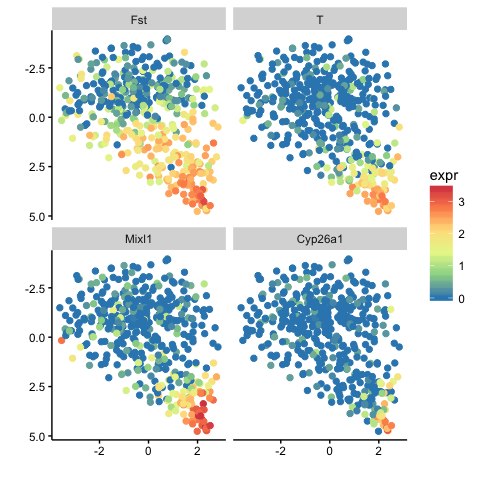

```r
plot_pp_scatter(pp_sig, log_marks = FALSE, scale_marks = FALSE, pal.direction = -1)
```

Plots with scaled expression per gene

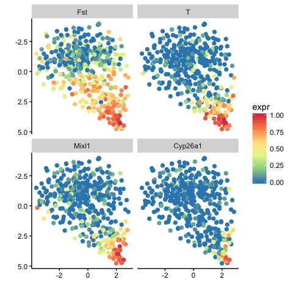

```r
plot_pp_scatter(pp_sig, log_marks = FALSE, scale_marks = TRUE, pal.direction = -1)
```

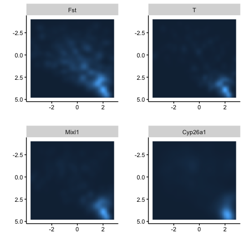

```
## [1] 1
## [1] 2
## [1] 3
## [1] 4
```

```r
plot_pp_density(pp_sig, log_marks = FALSE)
```